# Arboles de decison para Clasificacion

Rubén Pizarro

13/3/2020

#### Árboles de decisión para clasificación

#### Las librerías

```r
library(dplyr)
library(tidyverse)
library(rpart)
library(rpart.plot)
library(caret)
library(e1071)
```

#### Los datos

- No tienen nombres de columnas

```r
datos <- read.csv("../datos/wine.csv")
head(datos)
```

```
##   X1 X14.23 X1.71 X2.43 X15.6 X127 X2.8 X3.06 X.28 X2.29 X5.64 X1.04 X3.92
## 1  1  13.20  1.78  2.14  11.2  100 2.65  2.76 0.26  1.28  4.38  1.05  3.40
## 2  1  13.16  2.36  2.67  18.6  101 2.80  3.24 0.30  2.81  5.68  1.03  3.17
## 3  1  14.37  1.95  2.50  16.8  113 3.85  3.49 0.24  2.18  7.80  0.86  3.45
## 4  1  13.24  2.59  2.87  21.0  118 2.80  2.69 0.39  1.82  4.32  1.04  2.93
## 5  1  14.20  1.76  2.45  15.2  112 3.27  3.39 0.34  1.97  6.75  1.05  2.85
## 6  1  14.39  1.87  2.45  14.6   96 2.50  2.52 0.30  1.98  5.25  1.02  3.58
##   X1065
## 1  1050
## 2  1185
## 3  1480
## 4   735
## 5  1450
## 6  1290
```

```r
tail(datos)
```

```
##     X1 X14.23 X1.71 X2.43 X15.6 X127 X2.8 X3.06 X.28 X2.29 X5.64 X1.04 X3.92
## 172  3  14.16  2.51  2.48  20.0   91 1.68  0.70 0.44  1.24   9.7  0.62  1.71
## 173  3  13.71  5.65  2.45  20.5   95 1.68  0.61 0.52  1.06   7.7  0.64  1.74
## 174  3  13.40  3.91  2.48  23.0  102 1.80  0.75 0.43  1.41   7.3  0.70  1.56
## 175  3  13.27  4.28  2.26  20.0  120 1.59  0.69 0.43  1.35  10.2  0.59  1.56
## 176  3  13.17  2.59  2.37  20.0  120 1.65  0.68 0.53  1.46   9.3  0.60  1.62
## 177  3  14.13  4.10  2.74  24.5   96 2.05  0.76 0.56  1.35   9.2  0.61  1.60
##     X1065
## 172   660
## 173   740
## 174   750
## 175   835
## 176   840
## 177   560
```

#### Poner nombres de columnas

- 2. Alcohol. Porcentaje de alcohol
- 3. Malic acid Acido málico es un ácido de origen natural que está presente en muchos alimentos vegetales
- 4. Ash Ceniza. Producto de la incineración del extracto seco del vino, cuya composición varía según la naturaleza del suelo sobre el cual se ha desarrollado la uva.
- 5. Alcalinity of ash Alcalinidad de la ceniza
- 6. Magnesium. Magnesio
- 7. Total phenols. Fenoles totales
- 8. Flavanoids. Flavanoides
- 9. Nonflavanoid phenols. Fenoles No flavanoides
- 10. Proanthocyanins. Proantocianinos
- 11)Color intensity. Intensidad del color
- 12)Hue. Tono del color
- 13)OD280/OD315 of diluted wines. OD280/OD315 en vino diluido
- 14)Proline. Prolino

```r
colnames(datos) <- c("Tipo.Vino","Alcohol", "Malic.Acid","Ceniza","Alcal.Ceniza",
"Magnesio", "Fenols.Tot", "Flavanoides", "Fenoles.No.Flava",
"Proantocianinos", "Int.Color", "Tono.Color", "OD280.OD315", "Prolino")
head(datos)
```

```
##   Tipo.Vino Alcohol Malic.Acid Ceniza Alcal.Ceniza Magnesio Fenols.Tot
## 1         1   13.20       1.78   2.14         11.2      100       2.65
## 2         1   13.16       2.36   2.67         18.6      101       2.80
## 3         1   14.37       1.95   2.50         16.8      113       3.85
## 4         1   13.24       2.59   2.87         21.0      118       2.80
## 5         1   14.20       1.76   2.45         15.2      112       3.27
## 6         1   14.39       1.87   2.45         14.6       96       2.50
##   Flavanoides Fenoles.No.Flava Proantocianinos Int.Color Tono.Color OD280.OD315
## 1        2.76             0.26            1.28      4.38       1.05        3.40
## 2        3.24             0.30            2.81      5.68       1.03        3.17
## 3        3.49             0.24            2.18      7.80       0.86        3.45
## 4        2.69             0.39            1.82      4.32       1.04        2.93
## 5        3.39             0.34            1.97      6.75       1.05        2.85
## 6        2.52             0.30            1.98      5.25       1.02        3.58
##   Prolino
## 1    1050
## 2    1185
## 3    1480
## 4     735
## 5    1450
## 6    1290
```

```r
unique(datos$Tipo.Vino) # ¿Cuáles tipos de vinos existen ?
```

```
## [1] 1 2 3
```

#### Explorando los datos

- Primero factor a TipoVino

```r
datos$Tipo.Vino <- factor(datos$Tipo.Vino)
str(datos)
```

```
## 'data.frame':    177 obs. of  14 variables:
##  $ Tipo.Vino       : Factor w/ 3 levels "1","2","3": 1 1 1 1 1 1 1 1 1 1 ...
##  $ Alcohol         : num  13.2 13.2 14.4 13.2 14.2 ...
##  $ Malic.Acid      : num  1.78 2.36 1.95 2.59 1.76 1.87 2.15 1.64 1.35 2.16 ...
##  $ Ceniza          : num  2.14 2.67 2.5 2.87 2.45 2.45 2.61 2.17 2.27 2.3 ...
##  $ Alcal.Ceniza    : num  11.2 18.6 16.8 21 15.2 14.6 17.6 14 16 18 ...
##  $ Magnesio        : int  100 101 113 118 112 96 121 97 98 105 ...
##  $ Fenols.Tot      : num  2.65 2.8 3.85 2.8 3.27 2.5 2.6 2.8 2.98 2.95 ...
##  $ Flavanoides     : num  2.76 3.24 3.49 2.69 3.39 2.52 2.51 2.98 3.15 3.32 ...
##  $ Fenoles.No.Flava: num  0.26 0.3 0.24 0.39 0.34 0.3 0.31 0.29 0.22 0.22 ...
##  $ Proantocianinos : num  1.28 2.81 2.18 1.82 1.97 1.98 1.25 1.98 1.85 2.38 ...
##  $ Int.Color       : num  4.38 5.68 7.8 4.32 6.75 5.25 5.05 5.2 7.22 5.75 ...
##  $ Tono.Color      : num  1.05 1.03 0.86 1.04 1.05 1.02 1.06 1.08 1.01 1.25 ...
##  $ OD280.OD315     : num  3.4 3.17 3.45 2.93 2.85 3.58 3.58 2.85 3.55 3.17 ...
##  $ Prolino         : int  1050 1185 1480 735 1450 1290 1295 1045 1045 1510 ...
```

```r
summary(datos)
```

```
##  Tipo.Vino    Alcohol        Malic.Acid       Ceniza       Alcal.Ceniza
##  1:58      Min.   :11.03   Min.   :0.74   Min.   :1.360   Min.   :10.60
##  2:71      1st Qu.:12.36   1st Qu.:1.60   1st Qu.:2.210   1st Qu.:17.20
##  3:48      Median :13.05   Median :1.87   Median :2.360   Median :19.50
##            Mean   :12.99   Mean   :2.34   Mean   :2.366   Mean   :19.52
##            3rd Qu.:13.67   3rd Qu.:3.10   3rd Qu.:2.560   3rd Qu.:21.50
##            Max.   :14.83   Max.   :5.80   Max.   :3.230   Max.   :30.00
##     Magnesio        Fenols.Tot     Flavanoides    Fenoles.No.Flava
##  Min.   : 70.00   Min.   :0.980   Min.   :0.340   Min.   :0.1300
##  1st Qu.: 88.00   1st Qu.:1.740   1st Qu.:1.200   1st Qu.:0.2700
##  Median : 98.00   Median :2.350   Median :2.130   Median :0.3400
##  Mean   : 99.59   Mean   :2.292   Mean   :2.023   Mean   :0.3623
##  3rd Qu.:107.00   3rd Qu.:2.800   3rd Qu.:2.860   3rd Qu.:0.4400
##  Max.   :162.00   Max.   :3.880   Max.   :5.080   Max.   :0.6600
##  Proantocianinos   Int.Color        Tono.Color     OD280.OD315
##  Min.   :0.410   Min.   : 1.280   Min.   :0.480   Min.   :1.270
##  1st Qu.:1.250   1st Qu.: 3.210   1st Qu.:0.780   1st Qu.:1.930
##  Median :1.550   Median : 4.680   Median :0.960   Median :2.780
##  Mean   :1.587   Mean   : 5.055   Mean   :0.957   Mean   :2.604
##  3rd Qu.:1.950   3rd Qu.: 6.200   3rd Qu.:1.120   3rd Qu.:3.170
##  Max.   :3.580   Max.   :13.000   Max.   :1.710   Max.   :4.000
##     Prolino
##  Min.   : 278.0
##  1st Qu.: 500.0
##  Median : 672.0
##  Mean   : 745.1
##  3rd Qu.: 985.0
##  Max.   :1680.0
```

#### Crear datos de enrenamiento 70%

```r
set.seed(2020)
vino_entrenamiento <- sample_frac(datos, .7)
head(vino_entrenamiento)
```

```
##   Tipo.Vino Alcohol Malic.Acid Ceniza Alcal.Ceniza Magnesio Fenols.Tot
## 1         3   13.84       4.12   2.38         19.5       89       1.80
## 2         2   11.65       1.67   2.62         26.0       88       1.92
## 3         1   13.71       1.86   2.36         16.6      101       2.61
## 4         2   12.37       1.21   2.56         18.1       98       2.42
## 5         1   13.83       1.57   2.62         20.0      115       2.95
## 6         3   13.78       2.76   2.30         22.0       90       1.35
##   Flavanoides Fenoles.No.Flava Proantocianinos Int.Color Tono.Color OD280.OD315
## 1        0.83             0.48            1.56      9.01       0.57        1.64
## 2        1.61             0.40            1.34      2.60       1.36        3.21
## 3        2.88             0.27            1.69      3.80       1.11        4.00
## 4        2.65             0.37            2.08      4.60       1.19        2.30
## 5        3.40             0.40            1.72      6.60       1.13        2.57
## 6        0.68             0.41            1.03      9.58       0.70        1.68
##   Prolino
## 1     480
## 2     562
## 3    1035
## 4     678
## 5    1130
## 6     615
```

#### Crear datos de prueba o validación

- setdiff() del paquete base de R, establece la diferencia de un conjunto de datos con respecto a otro
- De vino_entrenamiento para determinar los datos de prueba

```r
vino_prueba <- setdiff(datos, vino_entrenamiento)
head(vino_prueba)
```

```
##   Tipo.Vino Alcohol Malic.Acid Ceniza Alcal.Ceniza Magnesio Fenols.Tot
## 1         1   13.24       2.59   2.87         21.0      118       2.80
## 2         1   14.39       1.87   2.45         14.6       96       2.50
## 3         1   13.86       1.35   2.27         16.0       98       2.98
## 4         1   14.12       1.48   2.32         16.8       95       2.20
## 5         1   13.75       1.73   2.41         16.0       89       2.60
## 6         1   12.93       3.80   2.65         18.6      102       2.41
##   Flavanoides Fenoles.No.Flava Proantocianinos Int.Color Tono.Color OD280.OD315
## 1        2.69             0.39            1.82      4.32       1.04        2.93
## 2        2.52             0.30            1.98      5.25       1.02        3.58
## 3        3.15             0.22            1.85      7.22       1.01        3.55
## 4        2.43             0.26            1.57      5.00       1.17        2.82
## 5        2.76             0.29            1.81      5.60       1.15        2.90
## 6        2.41             0.25            1.98      4.50       1.03        3.52
##   Prolino
## 1     735
## 2    1290
## 3    1045
## 4    1280
## 5    1320
## 6     770
```

#### Entrenando el modelo

```r
arbol <- rpart(formula = Tipo.Vino ~ ., data = vino_entrenamiento)
arbol
```

```
## n= 124
##
## node), split, n, loss, yval, (yprob)
##       * denotes terminal node
##
## 1) root 124 78 2 (0.35483871 0.37096774 0.27419355)
##   2) Prolino>=755 48  5 1 (0.89583333 0.06250000 0.04166667)
##     4) Flavanoides>=2.35 41  0 1 (1.00000000 0.00000000 0.00000000) *
##     5) Flavanoides< 2.35 7  4 2 (0.28571429 0.42857143 0.28571429) *
##   3) Prolino< 755 76 33 2 (0.01315789 0.56578947 0.42105263)
##     6) Int.Color< 4.79 45  4 2 (0.02222222 0.91111111 0.06666667) *
##     7) Int.Color>=4.79 31  2 3 (0.00000000 0.06451613 0.93548387) *
```

#### Generando el árbol

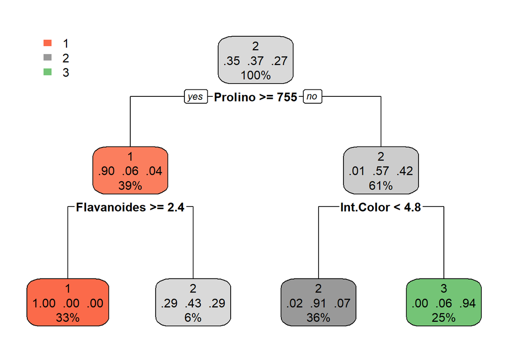

```r
rpart.plot(arbol)
```

- Dentro del rectángulo de cada nodo se muestra qué proporción de casos pertenecen a cada categoría y
- La proporción del total de datos que han sido agrupados allí.
- Por ejemplo, el rectángulo en el extremo inferior izquierdo de la gráfica tiene 100% de casos en el tipo 1, y 0% en los tipos 2 y 3, que representan 33% de todos los datos.

#### Generar predicciones con el modelo

```r
prediccion_1 <- predict(arbol, newdata = vino_prueba, type = "class")
```

#### Generando matriz de Confusión

```r
matriz.confusion_1 <- confusionMatrix(prediccion_1, vino_prueba[["Tipo.Vino"]])

matriz.confusion_1
```

```
## Confusion Matrix and Statistics
##
##           Reference
## Prediction  1  2  3
##          1 13  1  0
##          2  1 22  6
##          3  0  2  8
##
## Overall Statistics
##
##                Accuracy : 0.8113
##                  95% CI : (0.6803, 0.9056)
##     No Information Rate : 0.4717
##     P-Value [Acc > NIR] : 3.818e-07
##
##                   Kappa : 0.6968
##
##  Mcnemar's Test P-Value : NA
##
## Statistics by Class:
##
##                      Class: 1 Class: 2 Class: 3
## Sensitivity            0.9286   0.8800   0.5714
## Specificity            0.9744   0.7500   0.9487
## Pos Pred Value         0.9286   0.7586   0.8000
## Neg Pred Value         0.9744   0.8750   0.8605
## Prevalence             0.2642   0.4717   0.2642
## Detection Rate         0.2453   0.4151   0.1509
## Detection Prevalence   0.2642   0.5472   0.1887
## Balanced Accuracy      0.9515   0.8150   0.7601
```

```r
n <- nrow(vino_prueba) # Total de casos
print((13 + 22 + 8) / n * 100)
```

```
## [1] 81.13208
```

```r
print("Representa el 81% la probabilidad de Éxito del total de los datos")
```

```
## [1] "Representa el 81% la probabilidad de Éxito del total de los datos"
```

#### Construir otro modelo

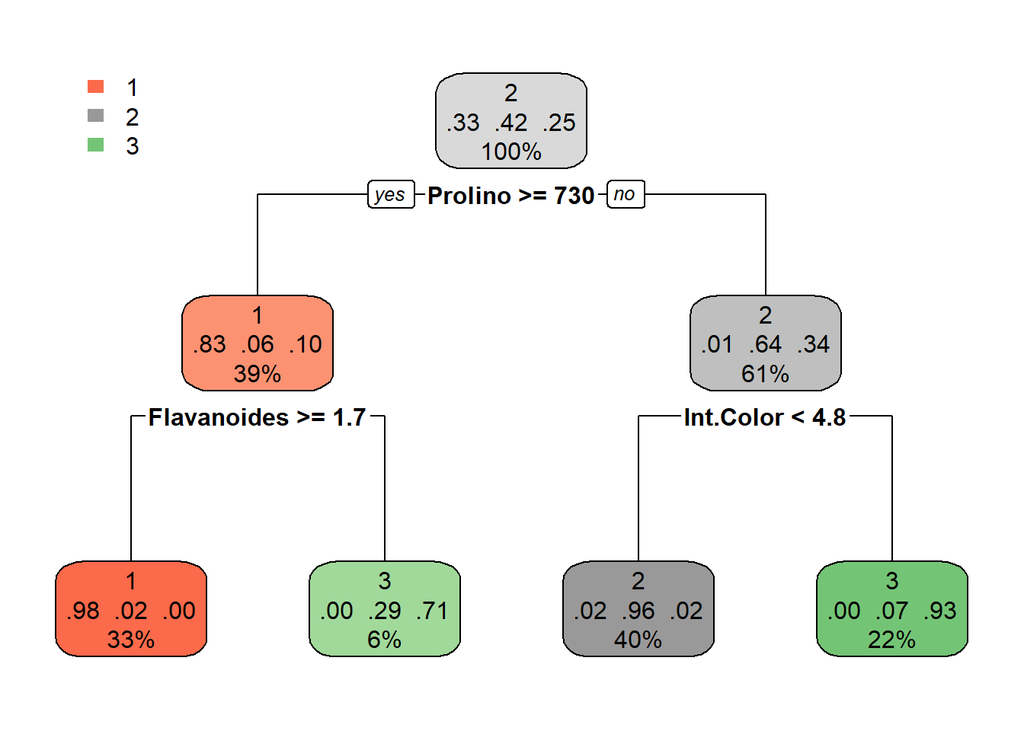

```r
set.seed(7439)
vino_entrenamiento_2 <- sample_frac(datos, .7)

vino_prueba_2 <- setdiff(datos, vino_entrenamiento)

arbol_2 <- rpart(formula = Tipo.Vino ~ ., data = vino_entrenamiento_2)

prediccion_2 <- predict(arbol_2, newdata = vino_prueba_2, type = "class")

rpart.plot(arbol_2)
```

#### Otra matriz de confusión con la prediccion_2

```r
matriz.confusion_2 <- confusionMatrix(prediccion_2, vino_prueba_2[["Tipo.Vino"]])

matriz.confusion_2
```

```
## Confusion Matrix and Statistics
##
##           Reference
## Prediction  1  2  3
##          1 14  1  0
##          2  0 22  2
##          3  0  2 12
##
## Overall Statistics
##
##                Accuracy : 0.9057
##                  95% CI : (0.7934, 0.9687)
##     No Information Rate : 0.4717
##     P-Value [Acc > NIR] : 2.81e-11
##
##                   Kappa : 0.853
##
##  Mcnemar's Test P-Value : NA
##
## Statistics by Class:
##
##                      Class: 1 Class: 2 Class: 3
## Sensitivity            1.0000   0.8800   0.8571
## Specificity            0.9744   0.9286   0.9487
## Pos Pred Value         0.9333   0.9167   0.8571
## Neg Pred Value         1.0000   0.8966   0.9487
## Prevalence             0.2642   0.4717   0.2642
## Detection Rate         0.2642   0.4151   0.2264
## Detection Prevalence   0.2830   0.4528   0.2642
## Balanced Accuracy      0.9872   0.9043   0.9029
```

```r
n <- nrow(vino_prueba_2) # Total de casos
print((14 + 22 + 12) / n * 100)
```

```
## [1] 90.56604
```

```r
print("Representa el 90.56% la probabilidad de Éxito del total de los datos")
```

```
## [1] "Representa el 90.56% la probabilidad de Éxito del total de los datos"
```

#### ¿Cómo elegimos un modelo?

- La respuesta depende de los objetivos y qué tanta precisión interese en las predicciones.
- Por ejemplo, con los datos sobre vinos podría ser que no interesan tanto las reglas específicas para clasificar vinos, sino las variables que son más importantes para distinguirlos.
- Lo que nos puede dar pauta areducir el número de variables usadas para catalogar vinos para fines de control de calidad, de las trece originales a un número menor.
- Por ejemplo, creamos cientos árboles con los mismos datos y después analizar los los modelos que tienen más éxito para clasificar para determinar cuáles variables son las que mejor separan los datos y en qué rangos se encuentran los valores de las reglas. De hecho, este es el principio del método Random Forest, Para otra ocasión

Pero también puede ser que el propósito del análisis sea clasificar vinos por riesgo de toxicidad. En este caso sí es importante tener reglas precisas para hacer predicciones.

En todo caso, una manera de elegir un modelo es, en realidad, crear múltiples modelos y compararlos. Por ejemplo, creamos cien árboles con los mismos datos y después analizaos los modelos que tienen más éxito para clasificar para determinar cuáles variables son las que mejor separan los datos y en qué rangos se encuentran los valores de las reglas. De hecho, este es el principio del método Random Forest, pero ese es tema para otro día.